# STOR 455 Quiz #2 v.B

**Directions:** This quiz is open books, notes, internet, and all things other than direct communication with others. The *Turtle_Quiz2.csv* dataset is needed to complete the quiz. This dataset can be imported from the chunk below or from the csv file, also attached in this Sakai assignment. You should complete the quiz in this R Notebook, including all code, plots, and explanations. For your submission, you should knit the notebook and submit it as a pdf to Gradescope.

```r
library(readr)
turtles =
  read_csv('https://raw.githubusercontent.com/JA-McLean/STOR455/master/data/Turtle_Quiz2.csv')
```

## Back to Eastern Box Turtles

The Box Turtle Connection is a long-term study anticipating at least 100 years of data collection on box turtles. Their purpose is to learn more about the status and trends in box turtle populations, identify threats, and develop strategies for long-term conservation of the species. Eastern Box Turtle populations are in decline in North Carolina and while they are recognized as a threatened species by the International Union for Conservation of Nature, the turtles have no protection in North Carolina. There are currently more than 30 active research study sites across the state of North Carolina. Turtles are weighed, measured, photographed, and permanently marked. These data, along with voucher photos (photos that document sightings), are then entered into centralized database managed by the NC Wildlife Resources Commission. The *Turtles_Quiz2.csv* dataset contains data collected at The Piedmont Wildlife Center in Durham.

In Homework #1, you may have have constructed a linear model with log(*Annuli*) as the response and log(*Mass*) as the predictor. This was a means to roughly estimate the age of the turtle from its mass. *Is it possible that other variables have a significant interaction with the relationship of these two variables?*

1. Construct a linear model with log(*Annuli*) as the response and log(*Mass*), *CaptureMethod*, and the interaction between log(*Mass*) and *CaptureMethod* as the predictors. Include the output for the summary of the model. Note that *CaptureMethod* uses the following numerical codes for how the turtle was captured: 1=road capture; 2=while mowing; 3=active search; 4=incidental; 5=radio signal; and 6=dog. *3pts*

```r
mod1 <- lm(log(Annuli)~log(Mass)+factor(CaptureMethod), turtles)
summary(mod1)
```

```
Call:
lm(formula = log(Annuli) ~ log(Mass) + factor(CaptureMethod),
    data = turtles)

Residuals:
     Min       1Q   Median       3Q      Max
-0.96021 -0.20466 -0.00636  0.17475  1.19524

Coefficients:
                       Estimate Std. Error t value Pr(>|t|)
(Intercept)            -0.92254    0.24891  -3.706 0.000251 ***
log(Mass)               0.66898    0.03758  17.799  < 2e-16 ***
factor(CaptureMethod)2 -0.35995    0.25739  -1.398 0.163009
factor(CaptureMethod)3 -0.15250    0.12559  -1.214 0.225597
factor(CaptureMethod)4 -0.10493    0.11743  -0.894 0.372307
factor(CaptureMethod)5 -0.14573    0.13727  -1.062 0.289252
factor(CaptureMethod)6  0.12961    0.18560   0.698 0.485495
---
Signif. codes:  0 ‘***’ 0.001 ‘**’ 0.01 ‘*’ 0.05 ‘.’ 0.1 ‘ ’ 1

Residual standard error: 0.3256 on 299 degrees of freedom
  (21 observations deleted due to missingness)
Multiple R-squared:  0.5287,    Adjusted R-squared:  0.5192
F-statistic: 55.89 on 6 and 299 DF,  p-value: < 2.2e-16
```

2. How many predictor variables are in the model that you constructed in question #1? *0.5pts*

3. Specifically for turtles who were captured via radio signal, for each 1 unit increase in log(*Mass*), what does your model from question #1 predict will be turtles’ increase in log(*Annuli*) (Your answer should be numerical)? *1.5pts*

```r
0.04149+0.12084
```

```
[1] 0.16233
```

```r
summary(mod1)
```

```
Call:
lm(formula = log(Annuli) ~ log(Mass) + factor(CaptureMethod),
    data = turtles)

Residuals:
     Min       1Q   Median       3Q      Max
-0.96021 -0.20466 -0.00636  0.17475  1.19524

Coefficients:
                       Estimate Std. Error t value Pr(>|t|)
(Intercept)            -0.92254    0.24891  -3.706 0.000251 ***
log(Mass)               0.66898    0.03758  17.799  < 2e-16 ***
factor(CaptureMethod)2 -0.35995    0.25739  -1.398 0.163009
factor(CaptureMethod)3 -0.15250    0.12559  -1.214 0.225597
factor(CaptureMethod)4 -0.10493    0.11743  -0.894 0.372307
factor(CaptureMethod)5 -0.14573    0.13727  -1.062 0.289252
factor(CaptureMethod)6  0.12961    0.18560   0.698 0.485495
---
Signif. codes:  0 ‘***’ 0.001 ‘**’ 0.01 ‘*’ 0.05 ‘.’ 0.1 ‘ ’ 1

Residual standard error: 0.3256 on 299 degrees of freedom
  (21 observations deleted due to missingness)
Multiple R-squared:  0.5287,    Adjusted R-squared:  0.5192
F-statistic: 55.89 on 6 and 299 DF,  p-value: < 2.2e-16
```

```r
exp(1.95887+0.16233)
```

```
[1] 8.341141
```

4. Perform a hypothesis test to determine the importance of just the terms that involve *CaptureMethod* in the model constructed in question #1. List your hypotheses (be specific!), p-value, and conclusion. *3pts*

*To find if CaptureMethod has a statistically signifigant effect on Annuli, we look at the individual t-tests for each variable. We want that eatch have a low p-value because it tells us that your variable is not expected by random chance.*

Ho: CaptureMethod = 0 Ha: CaptureMethod =/= 0

*Conclusion: We do not have evidence to reject the null hypothesis that CaptureMethod = 0 because the p-value is greater than 0.05.*

*Because teh pvalue is so high, currently, CaptureMethod is not a singifigicant variable in the model and may need to be removed and replaced with a different variable that would be a better predictor of Annuli*

```r
anova(mod1)
```

[output not shown]

5. Plot *Annuli* on the vertical axis and *Mass* on the horizontal axis (Not the log of these variables!). Your plot should still contain the data for all capture methods. Add the model that you are asked to construct in question #1 to this plot for specifically when the *CaptureMethod* was via radio signal. *2 pts*

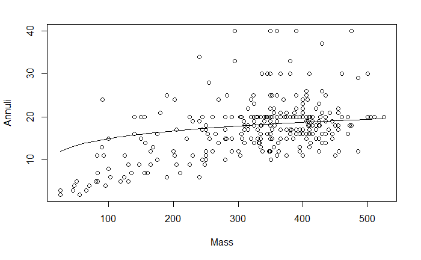

```r
plot(Annuli~Mass, turtles)
curve(exp(1.95887)* x^0.16233, add = TRUE)
```

```r
#For all the capture methods
plot(Annuli~Mass+factor(CaptureMethod), turtles)
# FOr only radio signal
plot(Annuli~Mass+factor(CaptureMethod==5, TRUE), turtles)
```

[output not shown]

```r
plot(Annuli~Mass+factor(CaptureMethod), turtles)
abline(mod1)
```

[output not shown]

```r
plot(Annuli~Mass, col = "red", subset(turtles, CaptureMethod==1))
points(Annuli~Mass, col="orange", subset(turtles, CaptureMethod==2))
points(Annuli~Mass, col="black", subset(turtles, CaptureMethod==3))
points(Annuli~Mass, col="green", subset(turtles, CaptureMethod==4))
points(Annuli~Mass, col="blue", subset(turtles, CaptureMethod==5))
points(Annuli~Mass, col="purple", subset(turtles, CaptureMethod==6))
```

[output not shown]